# Capstone Project For Credit Card Analysis

## Loading the libraries

```python
import pandas as pd
import numpy as np
import seaborn as sns
import matplotlib.pyplot as plt
from sklearn.preprocessing import MinMaxScaler
from sklearn.model_selection import train_test_split
from imblearn.over_sampling import ADASYN, KMeansSMOTE
from collections import Counter
import random
import logging

sns.set()
```

```python
import warnings
warnings.filterwarnings('ignore')
```

## Data Loading and Preparation

```python
df = pd.read_csv('UCI_Credit_Card.csv')
```

```python
print('shape of the dataset: {}'.format(df.shape))
```

```
shape of the dataset: (30000, 25)
```

```python
df.head()
```

|  | ID | LIMIT_BAL | SEX | EDUCATION | MARRIAGE | AGE | PAY_0 | PAY_2 | PAY_3 | PAY_4 | ... | BILL_AMT4 | BILL_AMT5 | BILL_AMT6 | PAY_AMT1 | PAY_AMT2 | PAY_AMT3 | PAY_AMT4 | PAY_AMT5 | PAY_AMT6 | default.payment.next.month |
| --- | --- | --- | --- | --- | --- | --- | --- | --- | --- | --- | --- | --- | --- | --- | --- | --- | --- | --- | --- | --- | --- |
| 0 | 1 | 20000.0 | 2 | 2 | 1 | 24 | 2 | 2 | -1 | -1 | ... | 0.0 | 0.0 | 0.0 | 0.0 | 689.0 | 0.0 | 0.0 | 0.0 | 0.0 | 1 |
| 1 | 2 | 120000.0 | 2 | 2 | 2 | 26 | -1 | 2 | 0 | 0 | ... | 3272.0 | 3455.0 | 3261.0 | 0.0 | 1000.0 | 1000.0 | 1000.0 | 0.0 | 2000.0 | 1 |
| 2 | 3 | 90000.0 | 2 | 2 | 2 | 34 | 0 | 0 | 0 | 0 | ... | 14331.0 | 14948.0 | 15549.0 | 1518.0 | 1500.0 | 1000.0 | 1000.0 | 1000.0 | 5000.0 | 0 |
| 3 | 4 | 50000.0 | 2 | 2 | 1 | 37 | 0 | 0 | 0 | 0 | ... | 28314.0 | 28959.0 | 29547.0 | 2000.0 | 2019.0 | 1200.0 | 1100.0 | 1069.0 | 1000.0 | 0 |
| 4 | 5 | 50000.0 | 1 | 2 | 1 | 57 | -1 | 0 | -1 | 0 | ... | 20940.0 | 19146.0 | 19131.0 | 2000.0 | 36681.0 | 10000.0 | 9000.0 | 689.0 | 679.0 | 0 |

5 rows × 25 columns

### Data information

```python
df.info()
```

```
<class 'pandas.core.frame.DataFrame'>
RangeIndex: 30000 entries, 0 to 29999
Data columns (total 25 columns):
 #   Column                      Non-Null Count  Dtype
---  ------                      --------------  -----
 0   ID                          30000 non-null  int64
 1   LIMIT_BAL                   30000 non-null  float64
 2   SEX                         30000 non-null  int64
 3   EDUCATION                   30000 non-null  int64
 4   MARRIAGE                    30000 non-null  int64
 5   AGE                         30000 non-null  int64
 6   PAY_0                       30000 non-null  int64
 7   PAY_2                       30000 non-null  int64
 8   PAY_3                       30000 non-null  int64
 9   PAY_4                       30000 non-null  int64
```

[output cut: 17 more lines]

### Checking of Missing Values

```python
missing_values = df.isnull().sum()
print(missing_values)
```

```
ID                            0
LIMIT_BAL                     0
SEX                           0
EDUCATION                     0
MARRIAGE                      0
AGE                           0
PAY_0                         0
PAY_2                         0
PAY_3                         0
PAY_4                         0
PAY_5                         0
PAY_6                         0
BILL_AMT1                     0
BILL_AMT2                     0
BILL_AMT3                     0
BILL_AMT4                     0
BILL_AMT5                     0
BILL_AMT6                     0
PAY_AMT1                      0
PAY_AMT2                      0
PAY_AMT3                      0
PAY_AMT4                      0
PAY_AMT5                      0
PAY_AMT6                      0
default.payment.next.month    0
dtype: int64
```

The output indicates that there are no missing values (NaNs) present in any of the columns of the DataFrame (`df`).

```python
df['SEX'].value_counts()
```

```
2    18112
1    11888
Name: SEX, dtype: int64
```

```python
df['EDUCATION'].value_counts()
```

```
2    14030
1    10585
3     4917
5      280
4      123
6       51
0       14
Name: EDUCATION, dtype: int64
```

```python
df['MARRIAGE'].value_counts()
```

```
2    15964
1    13659
3      323
0       54
Name: MARRIAGE, dtype: int64
```

```python
df['default.payment.next.month'].value_counts()
```

```
0    23364
1     6636
Name: default.payment.next.month, dtype: int64
```

```python
df['PAY_0'].value_counts()
```

```
 0    14737
-1     5686
 1     3688
-2     2759
 2     2667
 3      322
 4       76
 5       26
 8       19
 6       11
 7        9
Name: PAY_0, dtype: int64
```

```python
df['PAY_2'].value_counts()
```

```
 0    15730
-1     6050
 2     3927
-2     3782
 3      326
 4       99
 1       28
 5       25
 7       20
 6       12
 8        1
Name: PAY_2, dtype: int64
```

```python
df['PAY_3'].value_counts()
```

```
 0    15764
-1     5938
-2     4085
 2     3819
 3      240
 4       76
 7       27
 6       23
 5       21
 1        4
 8        3
Name: PAY_3, dtype: int64
```

```python
df['PAY_4'].value_counts()
```

```
 0    16455
-1     5687
-2     4348
 2     3159
 3      180
 4       69
 7       58
 5       35
 6        5
 1        2
 8        2
Name: PAY_4, dtype: int64
```

```python
df['PAY_5'].value_counts()
```

```
 0    16947
-1     5539
-2     4546
 2     2626
 3      178
 4       84
 7       58
 5       17
 6        4
 8        1
Name: PAY_5, dtype: int64
```

In the **EDUCATION** variable, we identified unexpected values **5**, **6**, and **0**. According to the data description, only the values **1**, **2**, **3**, and **4** are valid. We will combine **5**, **6**, and **0** into **4**, representing 'others.'

Similarly, for the **MARRIAGE** variable, an unexpected value **0** was found. We will merge **0** into **3**.

For the **PAY_n** variables, there are unexpected values **-2** and **0**. Further investigation is needed to determine the meaning of these values before deciding on the appropriate handling.

## Exploratory Data Analysis

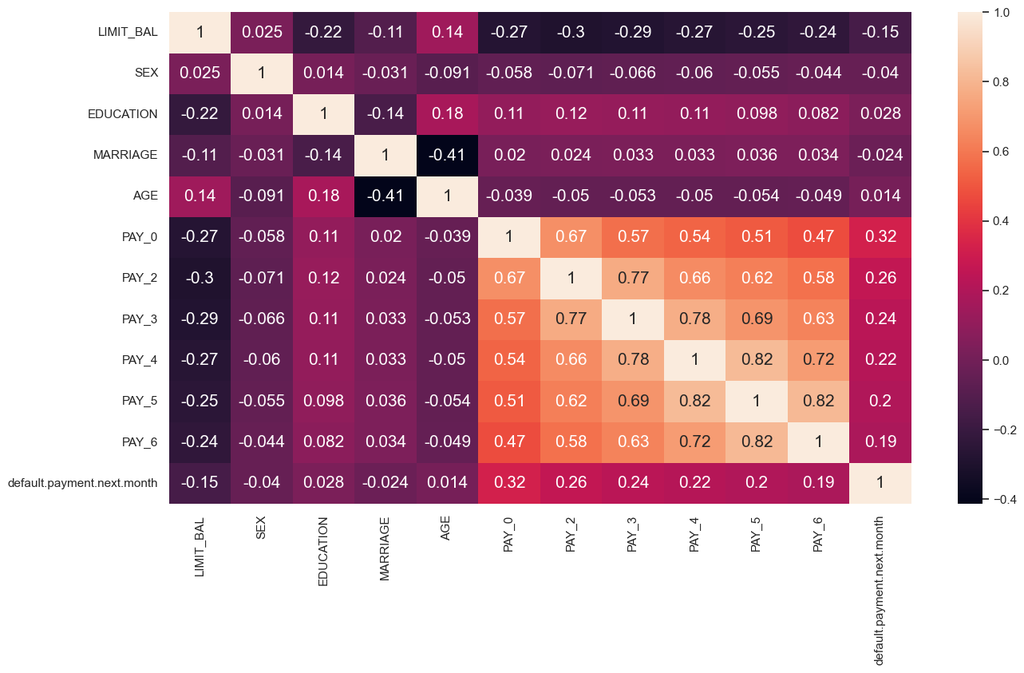

```python
corrdata=df[['LIMIT_BAL','SEX','EDUCATION','MARRIAGE','AGE','PAY_0','PAY_2','PAY_3','PAY_4','PAY_5','PAY_6','default.payment.next.month']]
corr = corrdata.corr()
plt.figure(figsize=(15,8))
sns.heatmap(corr, annot=True, annot_kws={"size": 15})
```

The provided heatmap is a correlation matrix that shows the relationships between various features in a dataset. Here is a summary of the key points:

1. **LIMIT_BAL (Credit Limit)**:
   - Negatively correlated with many variables, notably `PAY_0` to `PAY_6` (ranging from -0.24 to -0.3).
   - Slightly negatively correlated with `default.payment.next.month` (-0.15).
2. **SEX**:
   - Weak correlations with all other variables, with the highest being with `LIMIT_BAL` (0.025) and `AGE` (-0.091).
3. **EDUCATION**:
   - Moderately negatively correlated with `LIMIT_BAL` (-0.22) and `MARRIAGE` (-0.14).
   - Slight positive correlations with `PAY_0` to `PAY_6` (around 0.1 to 0.12).
4. **MARRIAGE**:
   - Moderately negatively correlated with `AGE` (-0.41).
   - Very weak correlations with other variables.
5. **AGE**:
   - Moderately negatively correlated with `MARRIAGE` (-0.41).
   - Slight positive correlation with `LIMIT_BAL` (0.14).
6. **PAY_0 to PAY_6 (Payment Statuses)**:
   - Strong positive correlations among themselves (ranging from 0.47 to 0.82).
   - Moderate positive correlations with `default.payment.next.month` (ranging from 0.19 to 0.32), indicating that higher payment status values (indicating delayed payments) are associated with higher chances of default.
7. **default.payment.next.month (Default Status)**:
   - Most strongly correlated with `PAY_0` (0.32), followed by `PAY_2` (0.26), and then `PAY_3` (0.24).

Overall, the heatmap indicates that variables related to payment status (`PAY_0` to `PAY_6`) have the strongest correlations with each other and with the likelihood of defaulting next month. Other variables like credit limit, age, and education exhibit weaker correlations with default status and each other.

## Histograms for numerical features

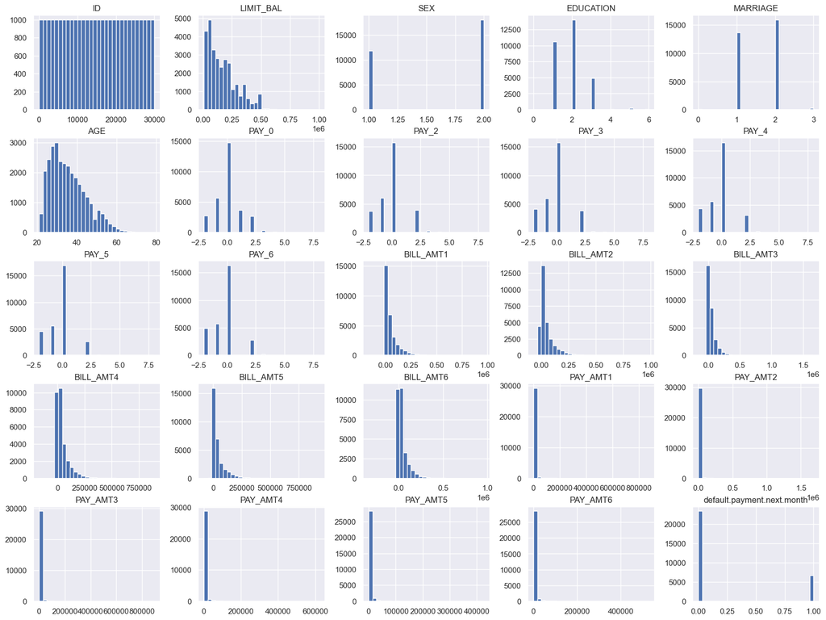

```python
df.hist(bins=30, figsize=(20, 15), layout=(5, 5))
plt.show()
```

The provided histograms display the distribution of various features in a dataset. Here’s a summary of each:

1. **ID**:
   - Uniform distribution, indicating IDs are evenly distributed across the range.
2. **LIMIT_BAL (Credit Limit)**:
   - Positively skewed distribution, with most values concentrated at the lower end (below 250,000).
3. **SEX**:
   - Bimodal distribution with two peaks, indicating two distinct categories.
4. **EDUCATION**:
   - Several distinct peaks, indicating discrete categories with the majority falling into a few specific categories (e.g., 1, 2, and 3).
5. **MARRIAGE**:
   - Few distinct categories, with the majority of the data concentrated in specific categories (e.g., 1 and 2).
6. **AGE**:
   - Positively skewed distribution, with most individuals falling between ages 20 and 50.
7. **PAY_0 to PAY_6 (Payment Statuses)**:
   - Concentrated around specific values (mostly 0 and -1), indicating most individuals have either no delay or are one month overdue.
   - Some long tails on the right, indicating a smaller number of individuals with higher delays.
8. **BILL_AMT1 to BILL_AMT6 (Bill Amounts)**:
   - Positively skewed distributions, with most values concentrated at the lower end.
   - Some long tails extending towards higher amounts, indicating a smaller number of high bill amounts.
9. **PAY_AMT1 to PAY_AMT6 (Payment Amounts)**:
   - Positively skewed distributions, with most values concentrated at the lower end.
   - Some long tails extending towards higher payment amounts, indicating a smaller number of high payment amounts.
10. **default.payment.next.month (Default Status)**:
    - Binary distribution, with two distinct peaks at 0 and 1, indicating a classification problem where 0 means no default and 1 means default.

Overall, the dataset appears to contain a mix of continuous and categorical variables, with many features exhibiting skewed distributions. Payment statuses and bill amounts show concentration around certain values, suggesting most individuals have consistent payment behaviors and bill amounts.

## Box plots for categorical features

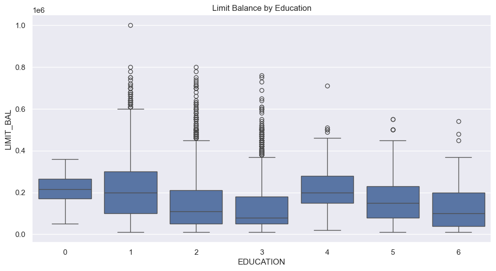

```python
plt.figure(figsize=(12, 6))
sns.boxplot(x='EDUCATION', y='LIMIT_BAL', data=df)
plt.title('Limit Balance by Education')
plt.show()
```

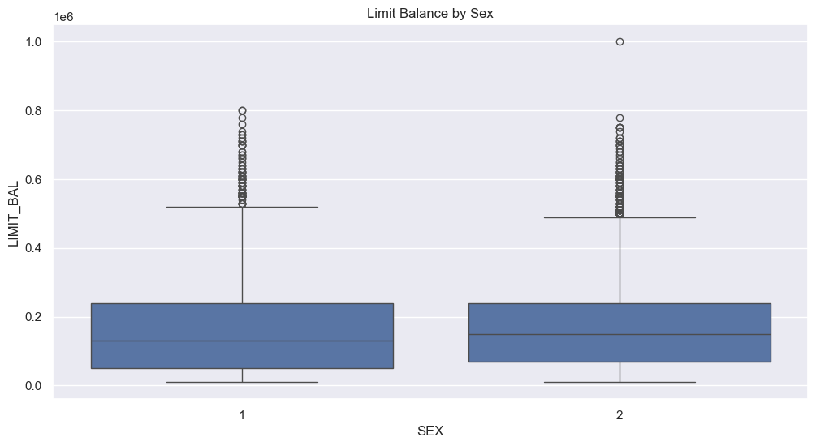

```python
plt.figure(figsize=(12, 6))
sns.boxplot(x='SEX', y='LIMIT_BAL', data=df)
plt.title('Limit Balance by Sex')
plt.show()
```

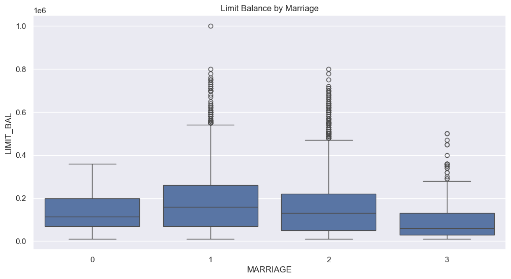

```python
plt.figure(figsize=(12, 6))
sns.boxplot(x='MARRIAGE', y='LIMIT_BAL', data=df)
plt.title('Limit Balance by Marriage')
plt.show()
```

This box plot shows the distribution of **LIMIT_BAL** (credit limit balance) by **MARRIAGE** status. Here's a summary:

Overall, **married (1)** and **single (2)** individuals tend to have higher and more variable credit limits, while **others (3)** and **unknown (0)** categories have lower median credit limits with less variability.

## Distribution of LIMIT_BAL

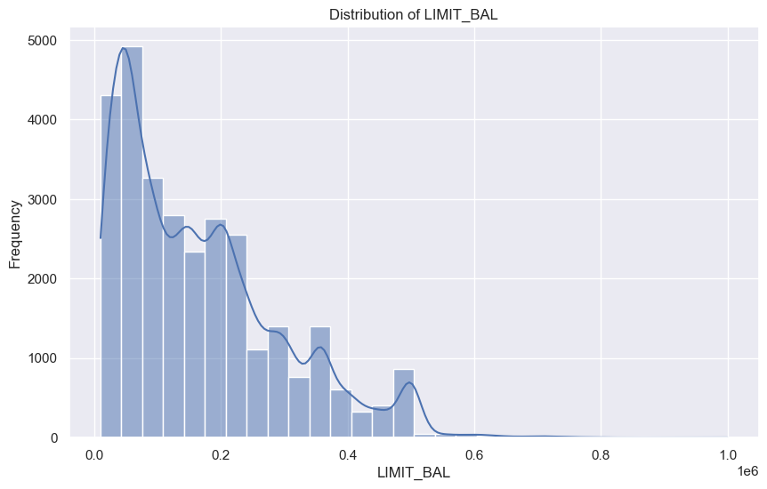

```python
plt.figure(figsize=(10, 6))
sns.histplot(df['LIMIT_BAL'], bins=30, kde=True)
plt.title('Distribution of LIMIT_BAL')
plt.xlabel('LIMIT_BAL')
plt.ylabel('Frequency')
plt.show()
```

# Feature Engineering

### Data Pre-processing and Preparation

**Ordinal variables: EDUCATION, PAY_n**

For the EDUCATION variable, which we treat as ordinal, we found unexpected values (5, 6, and 0) in addition to the expected values (1, 2, 3, and 4) specified in the data description. We've decided to consolidate values 5, 6, and 0 into a single category (4), representing 'other'.

Similarly, in the PAY_n variables, which are also treated as ordinal, we encountered unexpected values (-2 and 0).

```python
df['EDUCATION']= df['EDUCATION'].apply(lambda x:4 if x in [5,6,0] else x)
```

```python
df['EDUCATION'].value_counts()
```

```
2    14030
1    10585
3     4917
4      468
Name: EDUCATION, dtype: int64
```

```python
df[['PAY_0','BILL_AMT1','PAY_AMT1']][(df['PAY_0']==0) | (df['PAY_0'] ==-1)|(df['PAY_0'] ==-2)]
```

|  | PAY_0 | BILL_AMT1 | PAY_AMT1 |
| --- | --- | --- | --- |
| 1 | -1 | 2682.0 | 0.0 |
| 2 | 0 | 29239.0 | 1518.0 |
| 3 | 0 | 46990.0 | 2000.0 |
| 4 | -1 | 8617.0 | 2000.0 |
| 5 | 0 | 64400.0 | 2500.0 |
| ... | ... | ... | ... |
| 29992 | 0 | 8802.0 | 2000.0 |
| 29993 | 0 | 3042.0 | 2000.0 |
| 29995 | 0 | 188948.0 | 8500.0 |
| 29996 | -1 | 1683.0 | 1837.0 |
| 29999 | 0 | 47929.0 | 2078.0 |

23182 rows × 3 columns

**Norminal Variables: MARRIAGE and SEX**

We categorize MARRIAGE and SEX as nominal variables, indicating there is no inherent ordering among their categories.

In the MARRIAGE variable, as per the data description, there should be three values. However, we found an unexpected value (0). Our approach involves merging this value into category 3, representing 'other'. Subsequently, we apply one-hot encoding to create dummy variables for MARRIAGE.

```python
df['MARRIAGE'] = df['MARRIAGE'].apply(lambda x:3 if x==0 else x )
```

```python
df['MARRIAGE'].value_counts()
```

```
2    15964
1    13659
3      377
Name: MARRIAGE, dtype: int64
```

```python
class_counts = df['default.payment.next.month'].value_counts()
class_counts
```

```
0    23364
1     6636
Name: default.payment.next.month, dtype: int64
```

## Drop columns

```python
df = df.drop(['ID'], axis=1)
df['default.payment.next.month'] = df['default.payment.next.month'].astype(int)
```

## Creating New Features

```python
# 1. Credit Utilization Ratio
df['CREDIT_UTILIZATION'] = df[['BILL_AMT1', 'BILL_AMT2', 'BILL_AMT3', 'BILL_AMT4', 'BILL_AMT5', 'BILL_AMT6']].sum(axis=1) / df['LIMIT_BAL']

# 2. Average Payment
df['AVG_PAYMENT'] = df[['PAY_AMT1', 'PAY_AMT2', 'PAY_AMT3', 'PAY_AMT4', 'PAY_AMT5', 'PAY_AMT6']].mean(axis=1)

# 3. Payment to Income Ratio
df['PAYMENT_INCOME_RATIO'] = df[['PAY_AMT1', 'PAY_AMT2', 'PAY_AMT3', 'PAY_AMT4', 'PAY_AMT5', 'PAY_AMT6']].sum(axis=1) / df[['BILL_AMT1', 'BILL_AMT2', 'BILL_AMT3', 'BILL_AMT4', 'BILL_AMT5', 'BILL_AMT6']].sum(axis=1)

# 4. Number of Delayed Payments
df['NUM_DELAYED_PAYMENTS'] = (df[['PAY_0', 'PAY_2', 'PAY_3', 'PAY_4', 'PAY_5', 'PAY_6']] > 0).sum(axis=1)

# Handle infinite values that might occur from division
df.replace([np.inf, -np.inf], np.nan, inplace=True)
df.fillna(0, inplace=True)
```

## Creation of Dummy Variables

```python
# Identify categorical columns
categorical_cols = ['SEX', 'EDUCATION', 'MARRIAGE']

# Display unique values in these columns
for col in categorical_cols:
    print(f"{col}: {df[col].unique()}")

# Create dummy variables
df = pd.get_dummies(df, columns=categorical_cols, drop_first=True)
```

```
SEX: [2 1]
EDUCATION: [2 1 3 4]
MARRIAGE: [1 2 3]
```

```python
df.columns
```

```
Index(['LIMIT_BAL', 'AGE', 'PAY_0', 'PAY_2', 'PAY_3', 'PAY_4', 'PAY_5',
       'PAY_6', 'BILL_AMT1', 'BILL_AMT2', 'BILL_AMT3', 'BILL_AMT4',
       'BILL_AMT5', 'BILL_AMT6', 'PAY_AMT1', 'PAY_AMT2', 'PAY_AMT3',
       'PAY_AMT4', 'PAY_AMT5', 'PAY_AMT6', 'default.payment.next.month',
       'CREDIT_UTILIZATION', 'AVG_PAYMENT', 'PAYMENT_INCOME_RATIO',
       'NUM_DELAYED_PAYMENTS', 'SEX_2', 'EDUCATION_2', 'EDUCATION_3',
       'EDUCATION_4', 'MARRIAGE_2', 'MARRIAGE_3'],
      dtype='object')
```

```python
df.head()
```

|  | LIMIT_BAL | AGE | PAY_0 | PAY_2 | PAY_3 | PAY_4 | PAY_5 | PAY_6 | BILL_AMT1 | BILL_AMT2 | ... | CREDIT_UTILIZATION | AVG_PAYMENT | PAYMENT_INCOME_RATIO | NUM_DELAYED_PAYMENTS | SEX_2 | EDUCATION_2 | EDUCATION_3 | EDUCATION_4 | MARRIAGE_2 | MARRIAGE_3 |
| --- | --- | --- | --- | --- | --- | --- | --- | --- | --- | --- | --- | --- | --- | --- | --- | --- | --- | --- | --- | --- | --- |
| 0 | 20000.0 | 24 | 2 | 2 | -1 | -1 | -2 | -2 | 3913.0 | 3102.0 | ... | 0.385200 | 114.833333 | 0.089434 | 2 | 1 | 1 | 0 | 0 | 0 | 0 |
| 1 | 120000.0 | 26 | -1 | 2 | 0 | 0 | 0 | 2 | 2682.0 | 1725.0 | ... | 0.142308 | 833.333333 | 0.292791 | 2 | 1 | 1 | 0 | 0 | 1 | 0 |
| 2 | 90000.0 | 34 | 0 | 0 | 0 | 0 | 0 | 0 | 29239.0 | 14027.0 | ... | 1.129478 | 1836.333333 | 0.108388 | 0 | 1 | 1 | 0 | 0 | 1 | 0 |
| 3 | 50000.0 | 37 | 0 | 0 | 0 | 0 | 0 | 0 | 46990.0 | 48233.0 | ... | 4.626680 | 1398.000000 | 0.036259 | 0 | 1 | 1 | 0 | 0 | 0 | 0 |
| 4 | 50000.0 | 57 | -1 | 0 | -1 | 0 | 0 | 0 | 8617.0 | 5670.0 | ... | 2.186780 | 9841.500000 | 0.540054 | 0 | 0 | 1 | 0 | 0 | 0 | 0 |

5 rows × 31 columns

## Split the data into features (x) and target (y)

```python
X = df.drop(['default.payment.next.month'], axis=1)
y = df['default.payment.next.month']
```

```python
from imblearn.over_sampling import SMOTE
smote = SMOTE(random_state=42)
X_resampled, y_resampled = smote.fit_resample(X, y)
y_resampled.value_counts()
```

```
1    23364
0    23364
Name: default.payment.next.month, dtype: int64
```

```python
scaler = StandardScaler()
X_scaled = scaler.fit_transform(X_resampled)
```

```python
X_train, X_test, y_train, y_test = train_test_split(X_scaled, y_resampled, test_size=0.2, random_state=42)
```

## Model Development

```python
from sklearn.metrics import classification_report, roc_auc_score, confusion_matrix, accuracy_score, precision_score, recall_score, f1_score
```

## LOGISTIC REGRESSION MODEL

```python
logreg = LogisticRegression()
logreg.fit(X_scaled, y_resampled)

# # Evaluate the model
y_pred = logreg.predict(X_test)
y_proba = logreg.predict_proba(X_test)[:, 1]

accuracy = accuracy_score(y_test, y_pred)
precision = precision_score(y_test, y_pred)
recall = recall_score(y_test, y_pred)
f1 = f1_score(y_test, y_pred)
roc_auc = roc_auc_score(y_test, y_proba)

print(f"Accuracy: {accuracy:.4f}")
print(f"Precision: {precision:.4f}")
print(f"Recall: {recall:.4f}")
print(f"F1 Score: {f1:.4f}")
print(f"ROC-AUC: {roc_auc:.4f}")
print("Confusion Matrix:")
print(confusion_matrix(y_test, y_pred))
```

```
Accuracy: 0.7443
Precision: 0.7574
Recall: 0.7202
F1 Score: 0.7383
ROC-AUC: 0.8173
Confusion Matrix:
[[3584 1080]
 [1310 3372]]
```

```python
from statsmodels.stats.outliers_influence import variance_inflation_factor
from sklearn.preprocessing import StandardScaler
from sklearn.model_selection import train_test_split
from sklearn.linear_model import LogisticRegression
from sklearn.metrics import confusion_matrix, classification_report
X_scaled_df = pd.DataFrame(X_scaled, columns=X.columns)

def calculate_vif(df):
    vif = pd.DataFrame()
    vif["Features"] = df.columns
    vif["VIF"] = [variance_inflation_factor(df.values, i) for i in range(df.shape[1])]
    return vif

# Iteratively remove features with VIF > 10
while True:
    vif = calculate_vif(X_scaled_df)
    max_vif = vif['VIF'].max()
    if max_vif > 10:
        feature_to_remove = vif.loc[vif['VIF'].idxmax(), 'Features']
        print(f"Removing feature with highest VIF: {feature_to_remove} (VIF = {max_vif:.2f})")
        X_scaled_df = X_scaled_df.drop(columns=[feature_to_remove])
    else:
        break

print("Final set of features with VIF <= 10:")
print(calculate_vif(X_scaled_df))
```

```
Removing feature with highest VIF: PAY_AMT1 (VIF = inf)
Removing feature with highest VIF: BILL_AMT2 (VIF = 32.20)
Removing feature with highest VIF: BILL_AMT5 (VIF = 31.08)
Removing feature with highest VIF: BILL_AMT3 (VIF = 20.30)
Removing feature with highest VIF: AVG_PAYMENT (VIF = 17.29)
Removing feature with highest VIF: BILL_AMT4 (VIF = 12.72)
Final set of features with VIF <= 10:
                Features       VIF
0              LIMIT_BAL  2.323336
1                    AGE  1.311046
2                  PAY_0  2.217583
3                  PAY_2  3.524963
4                  PAY_3  3.972943
5                  PAY_4  4.818143
6                  PAY_5  5.471318
```

[output cut: 17 more lines]

## Rebuild the Logistic Regression model with the reduced set of features

```python
X_train, X_test, y_train, y_test = train_test_split(X_scaled_df, y_resampled, test_size=0.2, random_state=42)

model = LogisticRegression()
model.fit(X_train, y_train)

y_pred = model.predict(X_test)
conf_matrix = confusion_matrix(y_test, y_pred)
class_report = classification_report(y_test, y_pred)

print("Confusion Matrix:")
print(conf_matrix)
print("\nClassification Report:")
print(class_report)
```

```
Confusion Matrix:
[[3605 1059]
 [1328 3354]]

Classification Report:
              precision    recall  f1-score   support

           0       0.73      0.77      0.75      4664
           1       0.76      0.72      0.74      4682

    accuracy                           0.74      9346
   macro avg       0.75      0.74      0.74      9346
weighted avg       0.75      0.74      0.74      9346
```

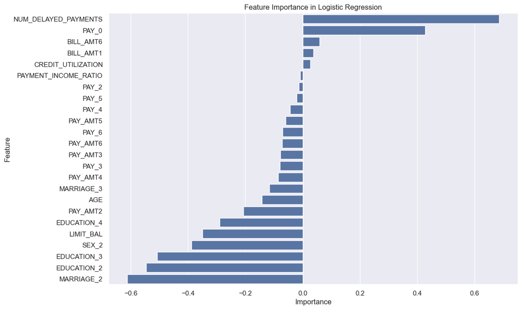

```python
log_reg = LogisticRegression(random_state=42)
log_reg.fit(X_scaled_df, y_resampled)

# Extract feature importances (coefficients)
feature_importance = log_reg.coef_[0]

# Create a DataFrame for plotting
features = X_train.columns
importance_df = pd.DataFrame({'Feature': features, 'Importance': feature_importance})

# Sort by importance
importance_df = importance_df.sort_values(by='Importance', ascending=False)

# Plot the feature importances
plt.figure(figsize=(12, 8))
sns.barplot(x='Importance', y='Feature', data=importance_df)
plt.title('Feature Importance in Logistic Regression')
plt.show()
```

## RANDOM FOREST

```python
X_train, X_test, y_train, y_test = train_test_split(X_scaled, y_resampled, test_size=0.2, random_state=42)
```

```python
rf = RandomForestClassifier()
rf.fit(X_train, y_train)
y_pred_rf = rf.predict(X_test)

# Evaluate the model
print("Random Forest Classification Report:")
print(classification_report(y_test, y_pred_rf))
print("AUC-ROC Score:", roc_auc_score(y_test, rf.predict_proba(X_test)[:, 1]))
```

```
Random Forest Classification Report:
              precision    recall  f1-score   support

           0       0.83      0.87      0.85      4664
           1       0.87      0.83      0.85      4682

    accuracy                           0.85      9346
   macro avg       0.85      0.85      0.85      9346
weighted avg       0.85      0.85      0.85      9346

AUC-ROC Score: 0.9178724878242501
```

## GRADIENT BOOSTING

```python
from sklearn.ensemble import GradientBoostingClassifier

# Gradient Boosting
gb = GradientBoostingClassifier()
gb.fit(X_train, y_train)
y_pred_gb = gb.predict(X_test)

# Evaluate the model
print("Gradient Boosting Classification Report:")
print(classification_report(y_test, y_pred_gb))
print("AUC-ROC Score:", roc_auc_score(y_test, gb.predict_proba(X_test)[:, 1]))
```

```
Gradient Boosting Classification Report:
              precision    recall  f1-score   support

           0       0.77      0.82      0.79      4664
           1       0.81      0.76      0.78      4682

    accuracy                           0.79      9346
   macro avg       0.79      0.79      0.79      9346
weighted avg       0.79      0.79      0.79      9346

AUC-ROC Score: 0.8636160081345073
```

```python
from xgboost import XGBClassifier
```

## XGBoost

```python
xgb_model = XGBClassifier(use_label_encoder=False, eval_metric='mlogloss')
xgb_model.fit(X_train, y_train)
xgb_predictions = xgb_model.predict(X_test)

# Evaluate the XGBoost model
xgb_accuracy = accuracy_score(y_test, xgb_predictions)
xgb_report = classification_report(y_test, xgb_predictions)

# Print evaluation results
print("XGBoost Accuracy:", xgb_accuracy)
print("XGBoost Classification Report:\n", xgb_report)
```

```
XGBoost Accuracy: 0.8289107639631929
XGBoost Classification Report:
               precision    recall  f1-score   support

           0       0.81      0.86      0.83      4664
           1       0.85      0.80      0.82      4682

    accuracy                           0.83      9346
   macro avg       0.83      0.83      0.83      9346
weighted avg       0.83      0.83      0.83      9346
```

```python
from sklearn.tree import DecisionTreeClassifier
```

## Decision Tree

```python
tree = DecisionTreeClassifier()
tree.fit(X_train, y_train)
y_pred_tree = tree.predict(X_test)
tree_report = classification_report(y_test, y_pred_tree)
tree_auc = roc_auc_score(y_test, tree.predict_proba(X_test)[:, 1])

print("Decision Tree Report:\n", tree_report)
print("Decision Tree ROC-AUC:", tree_auc)
```

```
Decision Tree Report:
               precision    recall  f1-score   support

           0       0.76      0.75      0.75      4664
           1       0.75      0.76      0.76      4682

    accuracy                           0.76      9346
   macro avg       0.76      0.76      0.76      9346
weighted avg       0.76      0.76      0.76      9346

Decision Tree ROC-AUC: 0.7565930760703192
```

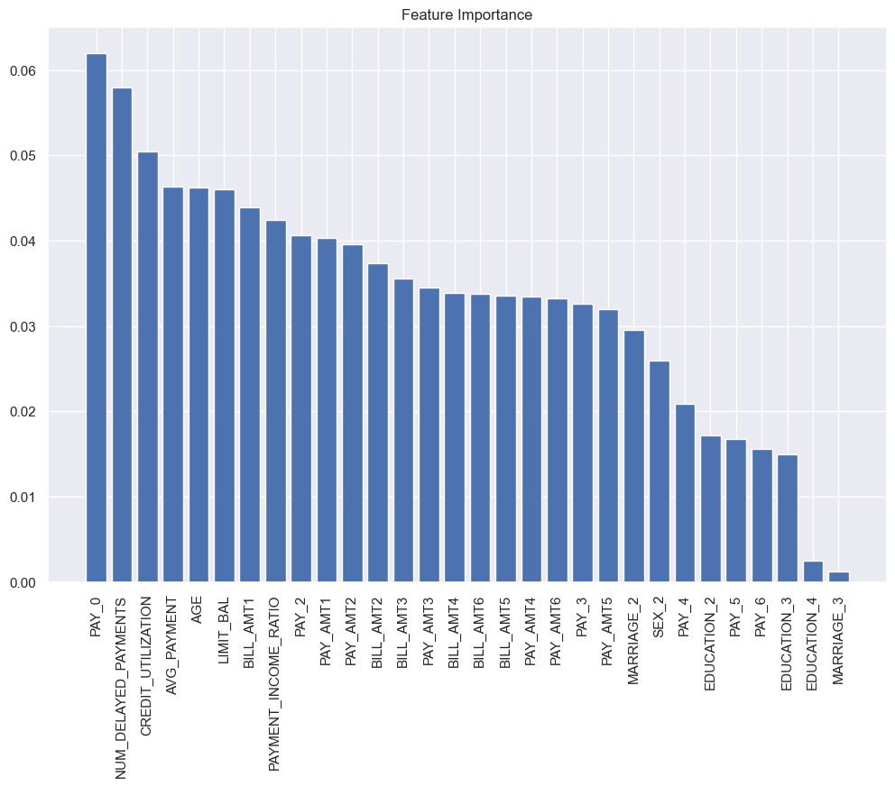

```python
importances = rf.feature_importances_
indices = np.argsort(importances)[::-1]

# Plot feature importances
plt.figure(figsize=(12, 8))
plt.title("Feature Importance")
plt.bar(range(X.shape[1]), importances[indices], align="center")
plt.xticks(range(X.shape[1]), X.columns[indices], rotation=90)
plt.show()
```